# STAT 420: Homework 07

Fall 2020, D. Unger

Due: Tuesday, October 27 by 11:30 PM CT

# Solution

## Exercise 1 (Brand Rankings)

For this exercise we will use the data stored in `cookies.csv`. In order to determine which of three recipes (`A`, `B`, and `C`) to use, a cookie manufacturer divided 18 individuals at random into three groups and asked each one of them to rate one recipe on a scale from 0 to 100.

Consider the model $y_{ij} = \mu + \alpha_i + e_{ij}$ where $\sum \alpha_i = 0$ and $e_{ij} \sim N(0,\sigma^{2})$. Here, $\mu + \alpha_i$ represents the mean of group (recipe) $i$.

Create side-by-side boxplots of the ratings of the three recipes. Test for a difference among the three recipes. If there is a difference, which recipes are different? Use $\alpha = 0.10$ for all tests. Which recipe would you use?

**Solution:**

```r
cookies = read.csv("cookies.csv")

summary(aov(rating ~ brand, data = cookies))
```

```
##             Df Sum Sq Mean Sq F value Pr(>F)
## brand        2    336     168   2.897 0.0864 .
## Residuals   15    870      58
## ---
## Signif. codes:  0 '***' 0.001 '**' 0.01 '*' 0.05 '.' 0.1 ' ' 1
```

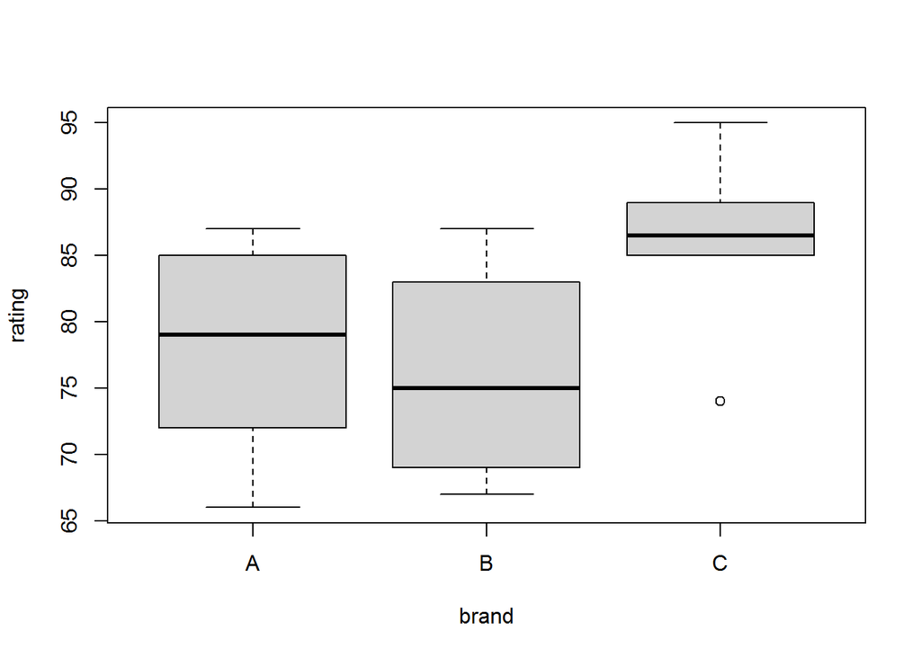

```r
boxplot(rating ~ brand, data = cookies)
```

```r
TukeyHSD(aov(rating ~ brand, data = cookies), conf.level = 0.90)
```

```
##   Tukey multiple comparisons of means
##     90% family-wise confidence level
##
## Fit: aov(formula = rating ~ brand, data = cookies)
##
## $brand
##     diff         lwr       upr     p adj
## B-A   -2 -11.7617067  7.761707 0.8930126
## C-A    8  -1.7617067 17.761707 0.1969983
## C-B   10   0.2382933 19.761707 0.0907760
```

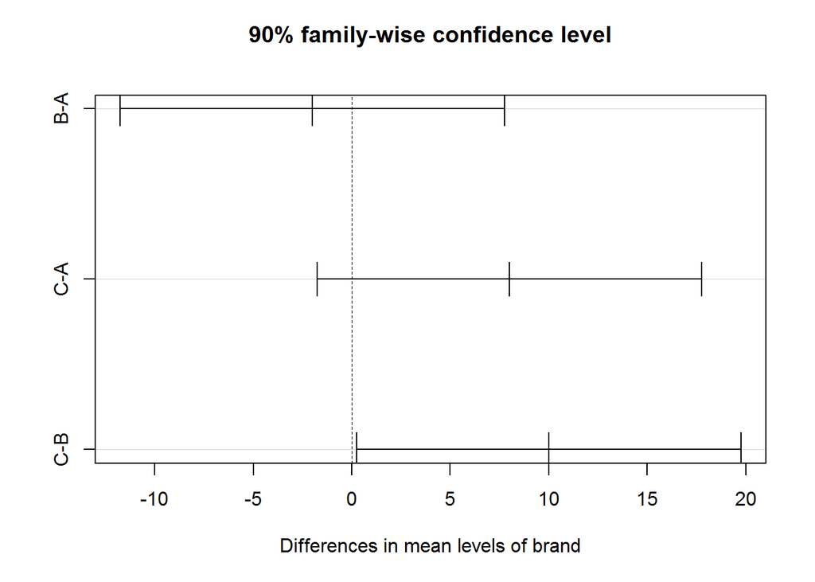

```r
plot(TukeyHSD(aov(rating ~ brand, data = cookies), conf.level = 0.90))
```

Based on the ANOVA test, there is a difference in the means of the three recipes at $\alpha = 0.10$. ($p = 0.086$)

Based on further testing using Tukey’s Honest Significant Differences, there is only a difference between recipes `B` and `C`. Since `C` has the highest sample mean, the manufacturer should use that recipe.

## Exercise 2 (Concrete Strength)

An engineer is investigating the strength of concrete beams made from four types of cement and employing three curing processes. For each cement-curing combination, three beams are made and their breaking strength is measured. (A $4 \times 3$ randomized factorial design with $3$ replicates.)

Consider the model:

$$y_{ijk} = \mu + \alpha_i + \beta_j + (\alpha \beta)_{ij} + \epsilon_{ijk}$$

where

$$i = 1, \cdots I \quad j = 1, \cdots J \quad k = 1 \cdots, K$$

and $\epsilon_{ijk}$ are $N(0, \sigma^2)$ random variables.

With constraints:

$$\sum \alpha_i = 0 \quad \quad \sum \beta_j = 0.$$

Additionally:

$$(\alpha \beta)_{1j} + (\alpha \beta)_{2j} + (\alpha \beta)_{3j} = 0 \\
(\alpha \beta)_{i1} + (\alpha \beta)_{i2} + (\alpha \beta)_{i3} + (\alpha \beta)_{i4} = 0$$

for any $i$ or $j$.

Let $\alpha_i$ represent the main effect for cement, which has four levels.

Let $\beta_j$ represent the main effect for curing process, which takes three levels.

The data can be found in `concrete.csv`. Test for interaction between the two factors. If necessary, test for main effects. Use $\alpha = 0.05$ for all tests. State the final model you choose. Also, create an interaction plot. Does this plot make sense for the model you chose? With the model you chose (and then fit), create a table that shows the estimated mean for each of the $4 \times 3$ factor level combinations.

**Solution:**

```r
concrete = read.csv("concrete.csv")
concrete$curing = as.factor(concrete$curing)
str(concrete)
```

```
## 'data.frame':    36 obs. of  3 variables:
##  $ curing  : Factor w/ 3 levels "1","2","3": 1 1 1 1 1 1 1 1 1 1 ...
##  $ cement  : chr  "A" "A" "A" "B" ...
##  $ strength: int  14 14 10 6 9 7 22 25 20 10 ...
```

```r
conc_int = aov(strength ~ curing * cement, data = concrete)
summary(conc_int)
```

```
##               Df Sum Sq Mean Sq F value   Pr(>F)
## curing         2   51.7   25.86   5.819   0.0087 **
## cement         3  929.0  309.66  69.673 5.46e-12 ***
## curing:cement  6   38.9    6.49   1.460   0.2337
## Residuals     24  106.7    4.44
## ---
## Signif. codes:  0 '***' 0.001 '**' 0.01 '*' 0.05 '.' 0.1 ' ' 1
```

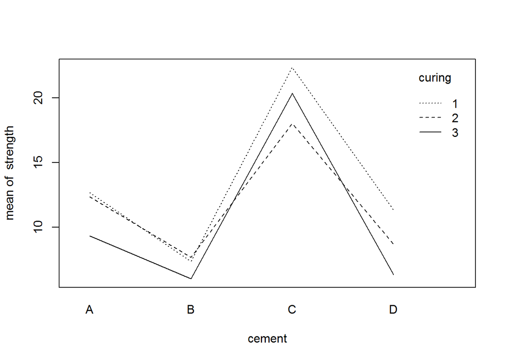

```r
with(concrete, interaction.plot(cement, curing, strength))
```

```r
conc_add = aov(strength ~ curing + cement, data = concrete)
conc_factor_levels = unique(concrete[,c("cement", "curing")])
conc_means = matrix(predict(conc_add, conc_factor_levels), 4, 3)

rownames(conc_means) = unique(concrete[,c("cement")])
colnames(conc_means) = unique(concrete[,c("curing")])
knitr::kable(conc_means)
```

|  | 1 | 2 | 3 |
| --- | --- | --- | --- |
| A | 13.000000 | 11.250000 | 10.083333 |
| B | 8.555556 | 6.805556 | 5.638889 |
| C | 21.777778 | 20.027778 | 18.861111 |
| D | 10.333333 | 8.583333 | 7.416667 |

## Exercise 3 (Weight Gain)

A total of $60$ rats were used in an experiment about the effects of protein quantity and source on weight gain. The experiment used a $2 \times 3$ randomized factorial design with $10$ replicates. (For each of the $6$ treatments, $10$ rats were randomly chosen.)

Each rat was fed a `low` or `high` protein diet from one of three sources: `beef`, `cereal`, or `pork`. After a period of time, the weight `gain` (the response, $y$) of each was measured in grams.

Consider the model:

$$y_{ijk} = \mu + \alpha_i + \beta_j + (\alpha \beta)_{ij} + \epsilon_{ijk}$$

where

$$i = 1, \cdots I \quad j = 1, \cdots J \quad k = 1 \cdots, K$$

and $\epsilon_{ijk}$ are $N(0, \sigma^2)$ random variables.

With constraints:

$$\sum \alpha_i = 0 \quad \quad \sum \beta_j = 0.$$

Additionally:

$$(\alpha \beta)_{1j} + (\alpha \beta)_{2j} + (\alpha \beta)_{3j} = 0 \\
(\alpha \beta)_{i1} + (\alpha \beta)_{i2} + (\alpha \beta)_{i3} + (\alpha \beta)_{i4} = 0$$

for any $i$ or $j$.

Let $\alpha_i$ represent the main effect for protein quantity, which has two levels; `high` and `low`.

Let $\beta_j$ represent the main effect for protein source, which takes three levels; `beef`, `cereal` and `pork`.

The data can be found in `rat_wt.csv`. Test for interaction between the two factors. If necessary, test for main effects. Use $\alpha = 0.10$ for all tests. State the final model you choose. Also, create an interaction plot. Does this plot make sense for the model you chose? With the model you chose (and then fit), create a table that shows the estimated mean for each of the $2 \times 3$ factor level combinations.

**Solution:**

```r
rat_wt = read.csv("rat_wt.csv")

rat_int = aov(gain ~ source * protein, data = rat_wt)
summary(rat_int)
```

```
##                Df Sum Sq Mean Sq F value Pr(>F)
## source          2    267   133.3   0.492 0.6139
## protein         1      0     0.1   0.000 0.9875
## source:protein  2   1318   658.9   2.434 0.0972 .
## Residuals      54  14615   270.6
## ---
## Signif. codes:  0 '***' 0.001 '**' 0.01 '*' 0.05 '.' 0.1 ' ' 1
```

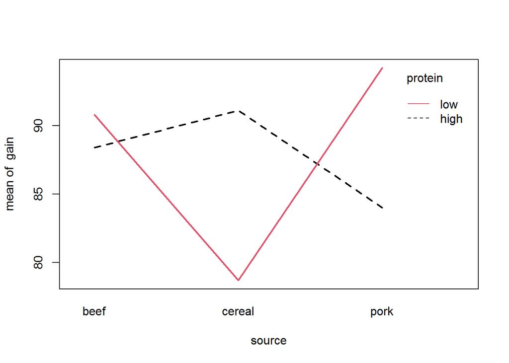

```r
with(rat_wt, interaction.plot(source, protein, gain, lwd = 2, col = c(1, 2)))
```

Based on the ANOVA table, we see that the interaction **is** significant using $\alpha = 0.10$ ($p = 0.097$), so we choose the **interaction** model.

This very clearly matches our expectation from the interaction plot, as the lines intersect multiple times. Notably, the relationship between `low` and `high` protein for `cereal` is the opposite of the other two sources.

```r
rat_factor_levels = unique(rat_wt[,c("source", "protein")])
rat_means = matrix(predict(rat_int, rat_factor_levels), 2, 3)

colnames(rat_means) = unique(rat_wt[,c("source")])
rownames(rat_means) = unique(rat_wt[,c("protein")])
knitr::kable(rat_means)
```

|  | beef | cereal | pork |
| --- | --- | --- | --- |
| high | 88.4 | 91.1 | 84.0 |
| low | 90.8 | 78.7 | 94.2 |

## Exercise 4 (Sample Size, Power)

Now that we’re performing experiments, getting more data means finding more test subjects, running more lab tests, etc. In other words, it will cost more time and money.

We’d like to design our experiment so that we have a good chance of detecting an interesting effect size, without spending too much money. There’s no point in running an experiment if there’s only a very low chance that it has a significant result **that you care about**. (Not all statistically significant results have practical value.)

Suppose we will run an experiment that compares three treatments: `A`, `B`, and `C`. From previous study, we believe the shared variance could be $\sigma^2 = 1$.

Consider the model $y_{ij} = \mu_j + e_{ij}$ where $e_{ij} \sim N(0,\sigma^{2})$. Here $j = 1, 2, 3$, for `A`, `B`, and `C`.

The null hypothesis of the test we will run is:

$$H_0: \mu_A = \mu_B = \mu_C$$

Suppose that we’re interested in an alternative where

$$\mu_A = -1, \mu_B = 0, \mu_C = 1$$

Mostly, we’ve used simulation to verify results. Now, we’ll use simulation to save money (in place of some rather difficult mathematics)!

Use simulation to determine the *minimum* sample size that has *at least* a 90% chance to reject the null hypothesis when that alternative is true and $\alpha = 0.05$. That is, find the sample size which gives a **power** of at least 0.90 for the stated alternative. Consider only balanced designs, which have the same number of replications in each group. For each sample size, use at least 250 simulations. (More simulations will give a better estimate of the power and will create a smoother resulting curve.)

Plot your results. What sample size do you choose?

Before performing the simulations, set a seed value equal to **your** birthday, as was done in the previous homework assignments.

```r
birthday = 18760613
set.seed(birthday)
```

**Solution:**

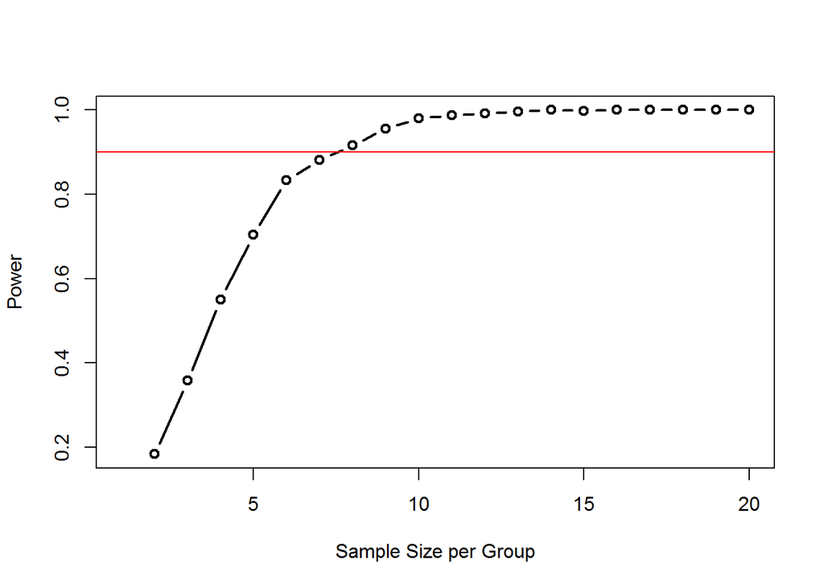

```r
library(broom)

size_sim = function(n = 2, mu_a = 0, mu_b = 0, mu_c = 0, sigma = 1) {

  # create data from one-way ANOVA model with three groups of equal size
  sim_data = data.frame(
    response = c(rnorm(n = n, mean = mu_a, sd = sigma),
                 rnorm(n = n, mean = mu_b, sd = sigma),
                 rnorm(n = n, mean = mu_c, sd = sigma)),
    group = c(rep("A", times = n), rep("B", times = n), rep("C", times = n))
  )

  # obtain p-value for testing difference of means
  glance(lm(response ~ group, data = sim_data))$p.value

}

max_n = 20 # max replicates per group to evaluate
powers = rep(0, max_n) # vector to store simulated powers

# for each number of replicates, perform 500 simulations
for (n in 1:max_n) {

  # obtain p-values of test for each of 500 simulations
  # use parameter values from alternative hypothesis
  p_vals = replicate(n = 500, size_sim(n = n, mu_a = -1, mu_b = 0, mu_c = 1, sigma = 1))

  # calculate power for specified alpha
  powers[n] = mean(p_vals < 0.05)
}

plot(powers, type = "b", lwd = 2,
     xlab = "Sample Size per Group", ylab = "Power")
abline(h = 0.90, col = "red")
```

```r
# get minimum replicates
num_reps = which.max(powers > 0.90) # returns first TRUE
# which.min would return first FALSE. R considers FALSE < TRUE

num_reps # minimum replicates
```

```
## [1] 8
```

```r
num_reps * 3 # minimum total sample size
```

```
## [1] 24
```

Based on the calculations and plots, we would need at least 8 observations in each group and thus 24 total observations in order to reach a power of at least 0.90 for the stated alternative.

## Exercise 5 (Balanced Design, Power)

Why do we use a balanced (equal number of replicates in each group) design? To maximize power. Let’s verify this with simulation.

Consider a simple example with $2$ groups A and B and a *total* sample size of $N = 10$. Where should we place these samples (replicates) between A and B? Obviously, at least one replicate needs to be in each, but after that, we can choose.

Consider the model $y_{ij} = \mu_j + e_{ij}$ where $e_{ij} \sim N(0,\sigma^{2} = 1)$. Here $j = 1, 2$, for `A` and `B`.

The null hypothesis of the test we will run is:

$$H_0: \mu_A = \mu_B$$

Suppose that we’re interested in an alternative where

$$\mu_A = 0, \mu_B = 2$$

Calculate the power for each of the possible placements of the replicates with $\alpha = 0.05$. (Essentially, for $n_a = 1, 2, \ldots 9$.) For each possibility, use at least 500 simulations. Plot the results. Does balance provide the best power?

Before performing the simulations, set a seed value equal to **your** birthday, as was done in the previous homework assignments.

```r
birthday = 17770430
set.seed(birthday)
```

**Solution:**

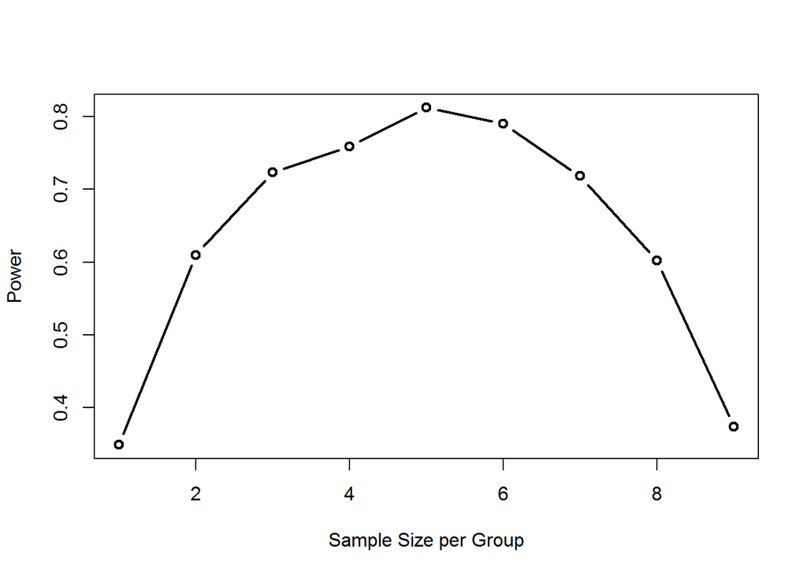

```r
balance_sim = function(n_a = 1, N = 20, mu_a = 0, mu_b = 0, sigma = 1) {

  # create data from one-way ANOVA model with two groups
  # size of group B is the remainder of the total N, after n_a are assigned to A
  sim_data = data.frame(
    response = c(rnorm(n = n_a, mean = mu_a, sd = sigma),
                 rnorm(n = N - n_a, mean = mu_b, sd = sigma)),
    group = c(rep("A", times = n_a), rep("B", times = N - n_a))
  )

  # obtain p-value for testing difference of means
  glance(lm(response ~ group, data = sim_data))$p.value

}

max_n_a = 9 # max replicates in group A
powers = rep(0, max_n_a) # vector to store simulated powers

# for each number of replicates in group A, perform 1000 simulations
for (n in 1:max_n_a) {

  # obtain p-values of test for each of 1000 simulations
  # use parameter values from alternative hypothesis
  p_vals = replicate(n = 1000, balance_sim(n_a = n, N = 10, mu_a = 0, mu_b = 2, sigma = 1))

  # calculate power for specified alpha
  powers[n] = mean(p_vals < 0.05)
}

plot(powers, type = "b", lwd = 2,
     xlab = "Sample Size per Group", ylab = "Power")
```

```r
# get minimum replicates
which.max(powers)
```

```
## [1] 5
```

The highest power is found with balance.